# 2_使用Keras对英文影评文本数据集进行二分类

## 2_使用Keras对英文影评文本数据集进行二分类

- 标签：文本分类、Keras、IMDB
- 难度：🌟🌟
- 参考：https://www.tensorflow.org/tutorials/keras/basic_text_classification
- 协议：MIT License

加载库，包括深度学习框架keras、用于数值计算的numpy、用于绘图的matplotlib

```python
import keras
from keras.datasets import imdb
import numpy as np
import matplotlib.pyplot as plt
%matplotlib inline
```

加载IMDB数据，没有则自动下载

- 训练集共2.5W条，测试集共2.5W条，每条数据都已经处理为整数序列，每个整数对应一个词
- `num_words`表示保留出现频次最高的若干个词，其他词对应的整数全部去除
- 标签共2类，消极或积极

```python
vocab_size = 10000
(X_train, Y_train), (X_test, Y_test) = imdb.load_data(num_words=vocab_size)

print('Train Set Number:', len(X_train), len(Y_train))
print(len(X_train[0]), Y_train[0])
print(X_train[0]) # 训练集的第一条数据长度为218，即包含218个词
```

```
Train Set Number: 25000 25000
218 1
[1, 14, 22, 16, 43, 530, 973, 1622, 1385, 65, 458, 4468, 66, 3941, 4, 173, 36, 256, 5, 25, 100, 43, 838, 112, 50, 670, 2, 9, 35, 480, 284, 5, 150, 4, 172, 112, 167, 2, 336, 385, 39, 4, 172, 4536, 1111, 17, 546, 38, 13, 447, 4, 192, 50, 16, 6, 147, 2025, 19, 14, 22, 4, 1920, 4613, 469, 4, 22, 71, 87,…
```

整理词到整数的映射，以及整数到词的映射，预留几个数字给一些特殊字符

```python
word2id = imdb.get_word_index()
word2id = {w: i + 3 for w, i in word2id.items()} # id从1开始
word2id['<PAD>'] = 0                             # 填充字符
word2id['<START>'] = 1                           # 句子的开始
word2id['<UNK>'] = 2                             # 词典以外的词
word2id['<UNUSED>'] = 3                          # 预留

id2word = {i: w for w, i in word2id.items()}     # id到词的映射

# 将id序列变为原始文本的函数
def decode_review(ids):
    return ' '.join([id2word.get(i, '?') for i in ids])

print(decode_review(X_train[0]))
```

```
<START> this film was just brilliant casting location scenery story direction everyone's really suited the part they played and you could just imagine being there robert <UNK> is an amazing actor and now the same being director <UNK> father came from the same scottish island as myself so i loved the…
```

进行预处理，将长句子进行截断、对短句子进行填充，使得序列长度统一

- `value`为用来填充的值
- `padding`和`truncating`默认都是`pre`，表示前向填充和前向截断，也可以设为`post`，表示后向填充和后向截断

```python
X_train = keras.preprocessing.sequence.pad_sequences(X_train, value=word2id['<PAD>'], padding='post', maxlen=256)
X_test = keras.preprocessing.sequence.pad_sequences(X_test, value=word2id['<PAD>'], padding='post', maxlen=256)
print([len(i) for i in X_train[:10]])
```

```
[256, 256, 256, 256, 256, 256, 256, 256, 256, 256]
```

定义模型并编译，从训练集中分割出一部分作为验证集（Validation Set），使用训练集和验证集训练模型

- `Embedding`对id序列进行嵌入，将每个id表示为向量，这样一来`25000*256`变成了`25000*256*16`
- `GlobalAveragePooling1D`对序列长度这一维度进行全局平均池化，这样一来`25000*256*16`变成了`25000*16`
- 多分类最后一层`Dense`一般用`softmax`激活函数，二分类则用`sigmoid`
- 二分类的损失函数一般用`binary_crossentropy`
- `batch_size`为训练的批大小，即每次使用若干条数据进行训练，如不提供则为32

```python
# 定义模型
model = keras.Sequential()
model.add(keras.layers.Embedding(vocab_size, 16))
model.add(keras.layers.GlobalAveragePooling1D())
model.add(keras.layers.Dense(16, activation='relu'))
model.add(keras.layers.Dense(1, activation='sigmoid'))
model.summary()

# 编译模型
model.compile(optimizer='adam', loss='binary_crossentropy', metrics=['accuracy'])

# 训练集和验证集分割
train_size = 20000
X_val = X_train[train_size:]
X_train = X_train[:train_size]
Y_val = Y_train[train_size:]
Y_train = Y_train[:train_size]

# 训练模型
history = model.fit(X_train, Y_train, epochs=40, batch_size=512, validation_data=(X_val, Y_val))
```

```
_________________________________________________________________
Layer (type)                 Output Shape              Param #
=================================================================
embedding_1 (Embedding)      (None, None, 16)          160000
_________________________________________________________________
global_average_pooling1d_1 ( (None, 16)                0
_________________________________________________________________
dense_1 (Dense)              (None, 16)                272
_________________________________________________________________
dense_2 (Dense)              (None, 1)                 17
=================================================================
Total params: 160,289
Trainable params: 160,289
Non-trainable params: 0
_________________________________________________________________
Train on 20000 samples, validate on 5000 samples
```

在测试集上评估模型，过拟合在验证集和测试集上都比较明显，最后使用训练过程的历史数据绘制一些图形

```
[0.37149411332130433, 0.86844]
dict_keys(['val_loss', 'val_acc', 'loss', 'acc'])
```

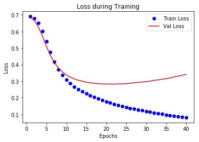

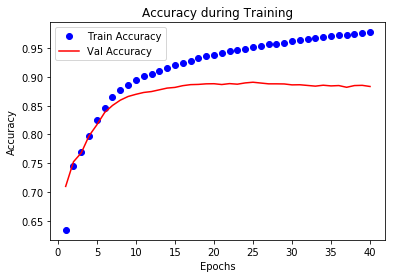

```python
results = model.evaluate(X_test, Y_test)
print(results)

history = history.history
print(history.keys())

acc = history['acc']
val_acc = history['val_acc']
loss = history['loss']
val_loss = history['val_loss']
xs = [i + 1 for i in range(len(loss))]

# 绘制损失函数曲线
plt.figure()
plt.plot(xs, loss, 'bo', label='Train Loss')
plt.plot(xs, val_loss, 'r', label='Val Loss')
plt.title('Loss during Training')
plt.xlabel('Epochs')
plt.ylabel('Loss')
plt.legend()
plt.show()

# 绘制正确率曲线
plt.figure()
plt.plot(xs, acc, 'bo', label='Train Accuracy')
plt.plot(xs, val_acc, 'r', label='Val Accuracy')
plt.title('Accuracy during Training')
plt.xlabel('Epochs')
plt.ylabel('Accuracy')
plt.legend()
plt.show()
```